# Exploring U.S. NOAA Storm Database

## How severe weather impact public health and economic

### Synopsis

Storms and other severe weather events can cause both public health and economic problems for communities and municipalities. Many severe events can result in fatalities, injuries, and property damage, and preventing such outcomes to the extent possible is a key concern.

This report explore the U.S. National Oceanic and Atmospheric Administration’s (NOAA) storm database and answer the following questions:

1.Across the United States, which types of events (as indicated in the Event variable) are most harmful with respect to population health?

2.Across the United States, which types of events have the greatest economic consequences?

This analysis shows the top 10 events that affect human health and ecnomics respectively. The results finds that that the **tornado** is most harmful for population health, and the **floods** results in greatest economic loss.

### Data Processing

First of all, set up the working environment for the analysis.

```r
rm(list=ls())
setwd("~/Desktop/Data Science @Coursera/Assignments/5_4")
library(reshape2)
library(ggplot2)
```

Then, download the raw data from the website. Note that the data is in a csv.bz2 file.

```r
if (!file.exists("stormdata.zip")){
      download.file("https://d396qusza40orc.cloudfront.net/repdata%2Fdata%2FStormData.csv.bz2", "stormdata.zip", method="curl")
}

storm <- read.csv("stormdata.zip",header = TRUE)
names(storm)
```

```
##  [1] "STATE__"    "BGN_DATE"   "BGN_TIME"   "TIME_ZONE"  "COUNTY"
##  [6] "COUNTYNAME" "STATE"      "EVTYPE"     "BGN_RANGE"  "BGN_AZI"
## [11] "BGN_LOCATI" "END_DATE"   "END_TIME"   "COUNTY_END" "COUNTYENDN"
## [16] "END_RANGE"  "END_AZI"    "END_LOCATI" "LENGTH"     "WIDTH"
## [21] "F"          "MAG"        "FATALITIES" "INJURIES"   "PROPDMG"
## [26] "PROPDMGEXP" "CROPDMG"    "CROPDMGEXP" "WFO"        "STATEOFFIC"
## [31] "ZONENAMES"  "LATITUDE"   "LONGITUDE"  "LATITUDE_E" "LONGITUDE_"
## [36] "REMARKS"    "REFNUM"
```

Since we don’t need all the variables, we will make a subset contain only what we need.

```r
dat <- storm[,c("EVTYPE","FATALITIES","INJURIES","PROPDMG","PROPDMGEXP","CROPDMG","CROPDMGEXP")]
rm(storm)
```

### Results

#### Weather events that are most harmful to population health

Figure out highest total affected population weather event type.

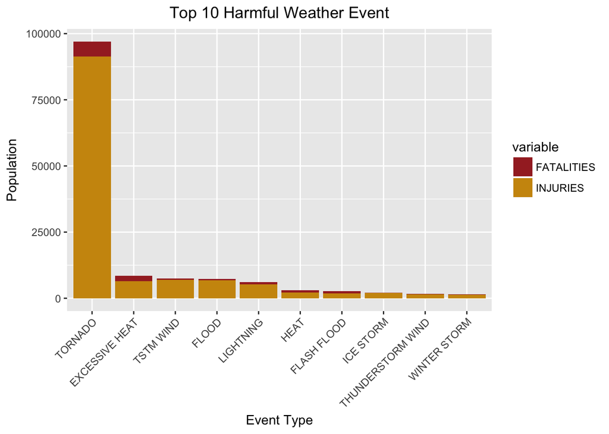

```r
pubH1 <- aggregate(FATALITIES ~ EVTYPE, dat,sum)
pubH2 <- aggregate(INJURIES ~ EVTYPE,dat,sum)
pubH <- merge(pubH1,pubH2,by="EVTYPE")
pubH$total <- pubH$FATALITIES+pubH$INJURIES
pubH <- pubH[order(-pubH$total),][1:10,]
pubH <- melt(pubH[1:10,1:3],id="EVTYPE",value.name = "count")
ggplot(pubH,aes(x=reorder(EVTYPE,-count),y=count,fill=variable)) +
      scale_fill_manual(values = c("brown","darkgoldenrod3")) +
      geom_bar(stat = "identity") +
      labs(x="Event Type",y="Population") +
      ggtitle("Top 10 Harmful Weather Event") +
      theme(plot.title = element_text(hjust=0.5),
            axis.text.x = element_text(angle = 45,hjust=1))
```

#### Weather events that have greatest economic consequences

When checking the data, it’s found that the damage costs are confusing in variables due to lack of official information in the NOAA website..

```r
summary(dat$PROPDMGEXP)
```

```
##             -      ?      +      0      1      2      3      4      5
## 465934      1      8      5    216     25     13      4      4     28
##      6      7      8      B      h      H      K      m      M
##      4      5      1     40      1      6 424665      7  11330
```

```r
summary(dat$CROPDMGEXP)
```

```
##             ?      0      2      B      k      K      m      M
## 618413      7     19      1      9     21 281832      1   1994
```

The variables `PROPDMGEXP` and `CROPDMGEXP` are dealt with according to the [anonymous post](https://rpubs.com/flyingdisc/PROPDMGEXP). The damage cost of property and crop are stored in the new varibles `propdc` and `cropdc`.

```r
dat$propdc[dat$PROPDMGEXP %in% c("","-","?")] <- 0
dat$propdc[dat$PROPDMGEXP=="+"] <- 1
dat$propdc[dat$PROPDMGEXP %in% c(0:8)] <- 10
dat$propdc[dat$PROPDMGEXP %in% c("h","H")] <- 100
dat$propdc[dat$PROPDMGEXP=="K"] <- 1000
dat$propdc[dat$PROPDMGEXP %in% c("m","M")] <- 1000000
dat$propdc[dat$PROPDMGEXP=="B"] <- 1000000000

dat$PROPDMG <-as.numeric(dat$PROPDMG)
dat$propdc <- as.numeric(dat$propdc)
dat$propdc <- dat$PROPDMG*dat$propdc

dat$cropdc[dat$CROPDMGEXP %in% c("","?")] <- 0
dat$cropdc[dat$CROPDMGEXP %in% c("0","2")] <- 10
dat$cropdc[dat$CROPDMGEXP %in% c("k","K")] <- 1000
dat$cropdc[dat$CROPDMGEXP %in% c("m","M")] <- 1000000
dat$cropdc[dat$CROPDMGEXP=="B"] <- 1000000000

dat$CROPDMG <-as.numeric(dat$CROPDMG)
dat$cropdc <- as.numeric(dat$cropdc)
dat$cropdc <- dat$CROPDMG*dat$cropdc
```

Then, figure out the highest total damage cost weather event type.

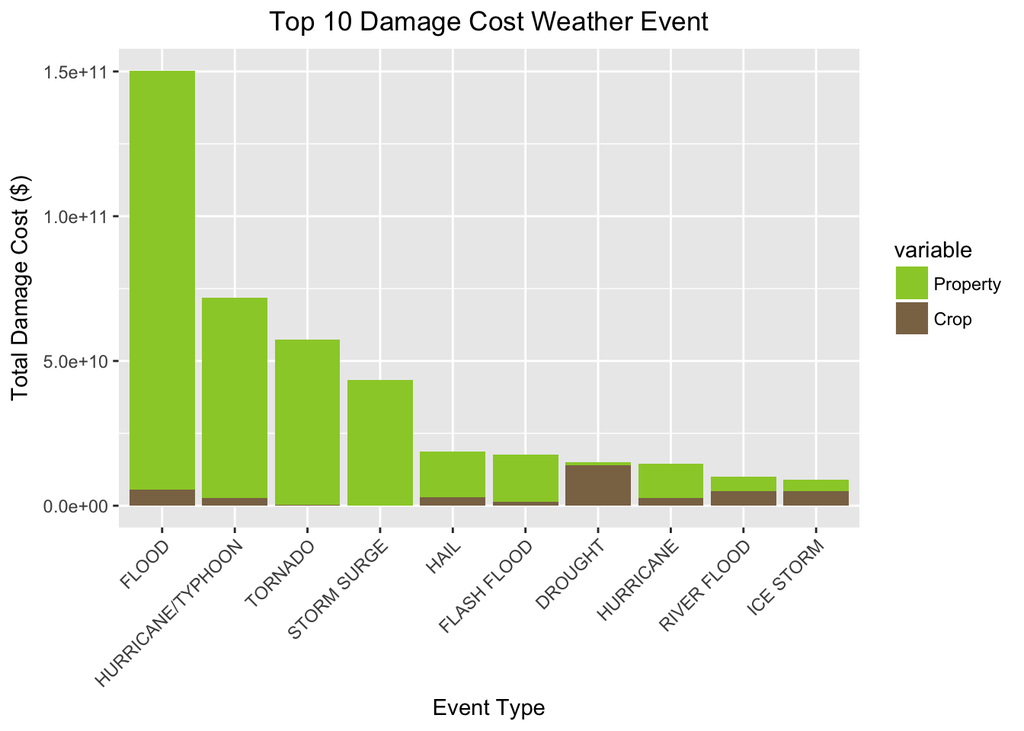

```r
dmg1 <- aggregate(propdc~EVTYPE,dat,sum)
dmg2 <- aggregate(cropdc~EVTYPE,dat,sum)
topdmg <- merge(dmg1,dmg2,by="EVTYPE")
topdmg$total <- topdmg$propdc+topdmg$cropdc
topdmg <- topdmg[order(-topdmg$total),][1:10,]
topdmg <- melt(topdmg[1:10,1:3],id="EVTYPE",value.name = "cost")
ggplot(topdmg,aes(x=reorder(EVTYPE,-cost),y=cost,fill=variable)) +
      scale_fill_manual(values = c("olivedrab3","burlywood4"),labels=c("Property","Crop")) +
      geom_bar(stat = "identity") +
      labs(x="Event Type",y="Total Damage Cost ($)") +
      ggtitle("Top 10 Damage Cost Weather Event") +
      theme(plot.title = element_text(hjust=0.5),
            axis.text.x = element_text(angle = 45,hjust=1))
```